# PetFinder Adoption Speed Analysis

Group 3: Data Torturers (Alexis Kaldany, Sahara Ensley, Yixi Liang, Kaiyuan Liang)

2021-11-04

# Chapter 1: Introduction

```r
library("corrplot")
library("ezids")
library("gtsummary")
## Loading data
data = read.csv('datafile.csv')

initialrows = nrow(data)

data$AdoptionSpeed <- factor(data$AdoptionSpeed, order=T, levels = c(0,1,2,3,4))

# converting the data types we want - categorical
data$Type = as.factor(data$Type)
data$MaturitySize = as.factor(data$MaturitySize)
data$FurLength = as.factor(data$FurLength)
data$Vaccinated = as.factor(data$Vaccinated)
data$Gender = as.factor(data$Gender)

# Only looking at profiles with 1 animal
data = subset(data, data$Quantity == 1)
data = subset(data, ! data$AdoptionSpeed == 4)

# Only pulling the columns we want to look at
dat = data[c('Type', 'Age', 'Gender', 'MaturitySize', 'FurLength', 'Vaccinated', 'PhotoAmt','VideoAmt', 'AdoptionSpeed')]
summary(dat)

# Adding random values
dat$ASnum = NaN
dat$ASnum[dat$AdoptionSpeed == 0] = 0
dat$ASnum[dat$AdoptionSpeed == 1] = floor(runif(sum(dat$AdoptionSpeed == 1), 1, 8))
dat$ASnum[dat$AdoptionSpeed == 2] = floor(runif(sum(dat$AdoptionSpeed == 2), 8, 31))
dat$ASnum[dat$AdoptionSpeed == 3] = floor(runif(sum(dat$AdoptionSpeed == 3), 31, 91))
#dat$ASnum[dat$AdoptionSpeed == 4] = 100 -- this line isn't necessary because we exclude animals that have this adoption speed

summary(dat)
```

This dataset came from Kaggle (https://www.kaggle.com/c/petfinder-adoption-prediction/data) and contains information about pet profiles that were listed for adoption on PetFinder.

# Chapter 2: Data description and cleaning

Initially this dataset contained 14993 observations of 24 variables with an ordinal dependent variable of `AdoptionSpeed.`

We took a few initial steps to clean this dataset. First, we removed any animal profiles that had more than 1 pet (`quantity = 1`) to reduce the chance of a confounding variable. We then removed any pets that had a categorical adoption speed of 4 because that meant the animal had not been adopted. We decided to keep 8 independent variables for analysis: `Type`, `Age`, `Gender`, `MaturitySize`, `FurLength`, `Vaccinated`, `PhotoAmt`, and `VideoAmt.` The final pre-processing step that we took was to convert the dependent variable `AdoptionSpeed` to a continuous numerical variable `ASnum.` We did this by generating uniform random integers between the intervals that were specified by the dataset for each `AdoptionSpeed` bucket. The resulting dependent variable has values ranging from 0 to 90 days listed on PetFinder.

Our final dataset looks like this at a glance:

```r
summary(dat)
```

```
##  Type          Age        Gender   MaturitySize FurLength Vaccinated
##  1:4754   Min.   :  0.0   1:3837   1:1890       1:4776    1:3498
##  2:3731   1st Qu.:  2.0   2:4648   2:5816       2:3109    2:3939
##           Median :  3.0   3:   0   3: 751       3: 600    3:1048
##           Mean   : 10.3            4:  28
##           3rd Qu.:  9.0
##           Max.   :212.0
##     PhotoAmt        VideoAmt    AdoptionSpeed     ASnum
##  Min.   : 0.00   Min.   :0.00   0: 331        Min.   : 0.0
##  1st Qu.: 2.00   1st Qu.:0.00   1:2439        1st Qu.: 6.0
##  Median : 3.00   Median :0.00   2:3163        Median :18.0
##  Mean   : 3.81   Mean   :0.06   3:2552        Mean   :26.6
##  3rd Qu.: 5.00   3rd Qu.:0.00   4:   0        3rd Qu.:41.0
##  Max.   :30.00   Max.   :6.00                 Max.   :90.0
```

It contains 8485 observations of 10 variables, including both `AdoptionSpeed` and `ASnum`. Here is a look at the first 3 rows of the cleaned dataset.

```r
head(dat, 3)
```

```
##   Type Age Gender MaturitySize FurLength Vaccinated PhotoAmt VideoAmt
## 1    2   3      1            1         1          2        1        0
## 2    2   1      1            2         2          3        2        0
## 3    1   1      1            2         2          1        7        0
##   AdoptionSpeed ASnum
## 1             2    21
## 2             0     0
## 3             3    31
```

In order to make sense of the numbers for the variables we use the metadata from the dataset description on Kaggle to decode categorical values.

AdoptionSpeed - Categorical speed of adoption. Lower is faster.  
Type - Type of animal (1 = Dog, 2 = Cat)  
Age - Age of pet when listed, in months  
Gender - Gender of pet (1 = Male, 2 = Female, 3 = Mixed, if profile represents group of pets)  
MaturitySize - Size at maturity (1 = Small, 2 = Medium, 3 = Large, 4 = Extra Large, 0 = Not Specified)  
FurLength - Fur length (1 = Short, 2 = Medium, 3 = Long, 0 = Not Specified)  
Vaccinated - Pet has been vaccinated (1 = Yes, 2 = No, 3 = Not Sure)  
PhotoAmt - Total uploaded photos for this pet  
PhotoAmt - Total uploaded videos for this pet

# Chapter 3: Independent Variables EDA

### Numerical variable

In this chapter we will introduce some variables. The first one is AdoptionSpeed.

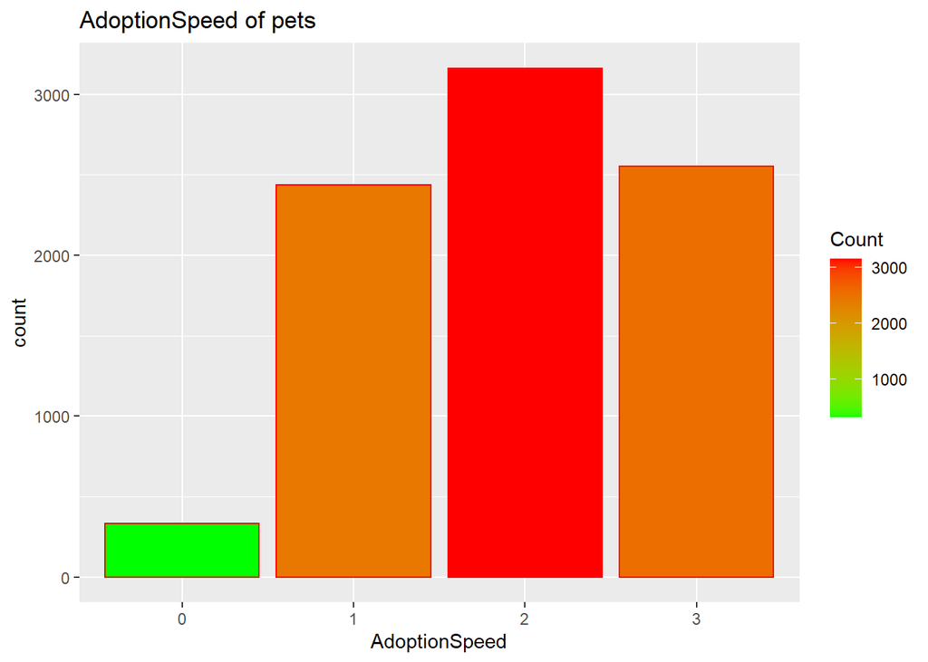

```r
loadPkg("ggplot2")
#Histogram
ggplot(data=dat, aes(AdoptionSpeed)) +
  geom_bar(breaks=seq(0, 4, by=1),
                 col="red",
                 aes(fill=..count..)) +
  labs(title="AdoptionSpeed of pets", x = "AdoptionSpeed") +
  scale_fill_gradient("Count", low="green", high="red")
```

AdoptionSpeed is divided into 4 levels.  
0 means pet was adopted on the same day as it was listed.  
1 Pet was adopted between 1 and 7 days (1st week).  
2 Pet was adopted between 8 and 30 days (1st month) after being listed.  
3 Pet was adopted between 31 and 90 days (2nd & 3rd month) after being listed.  
4 No adoption after 100 days of being listed. (we drop this level)  
We transformed AdoptionSpeed to numerical variable: ASnum.

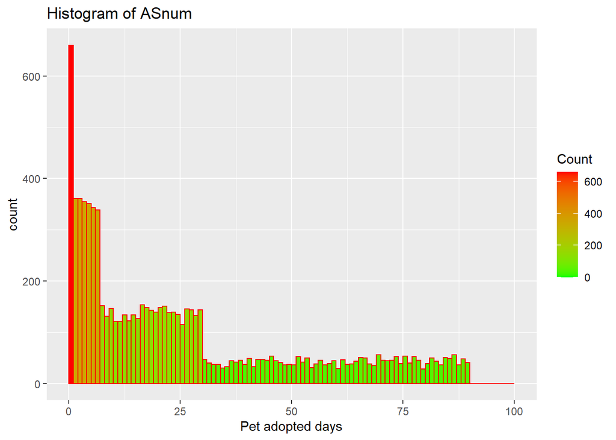

```r
ggplot(data=dat, aes(dat$ASnum)) +
  geom_histogram(breaks=seq(0, 100, by=1),
                 col="red",
                 aes(fill=..count..)) +
  labs(title="Histogram of ASnum", x="Pet adopted days") +
  scale_fill_gradient("Count", low="green", high="red")
```

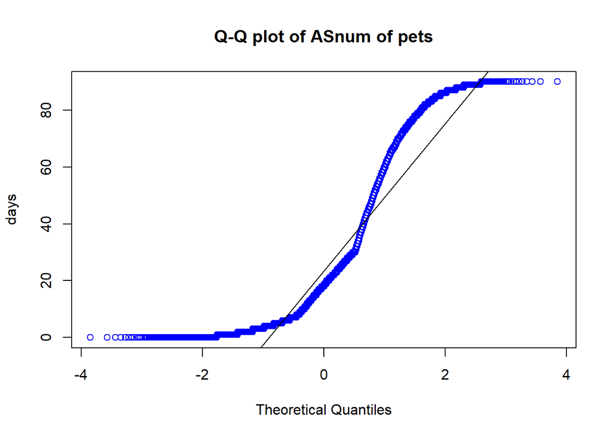

```r
#Q-Q plot
qqnorm(dat$ASnum, main="Q-Q plot of ASnum of pets", ylab = "days",col="blue")
qqline(dat$ASnum)
```

This is Age. Although this variable is age, it represents the number of months since birth when they were listed on PetFinder. It is obviously that most of the pets are young, which makes sense that their owners do not have enough energy to take care of so many baby pets after their pets give birth to puppies and kittens.

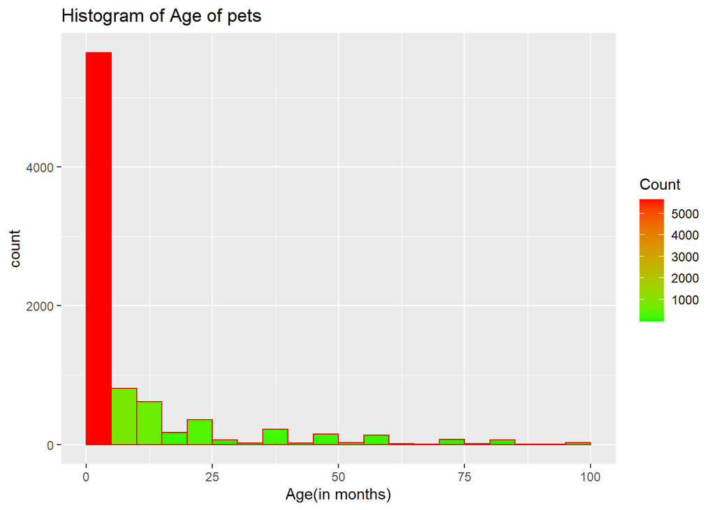

```r
tmpDatAge = dat
tmpDatAge$Age = as.numeric(dat$Age)

ggplot(data=tmpDatAge, aes(Age)) +
  geom_histogram(breaks=seq(0, 100, by=5),
                 col="red",
                 aes(fill=..count..)) +
  labs(title="Histogram of Age of pets", x="Age(in months)") +
  scale_fill_gradient("Count", low="green", high="red")
```

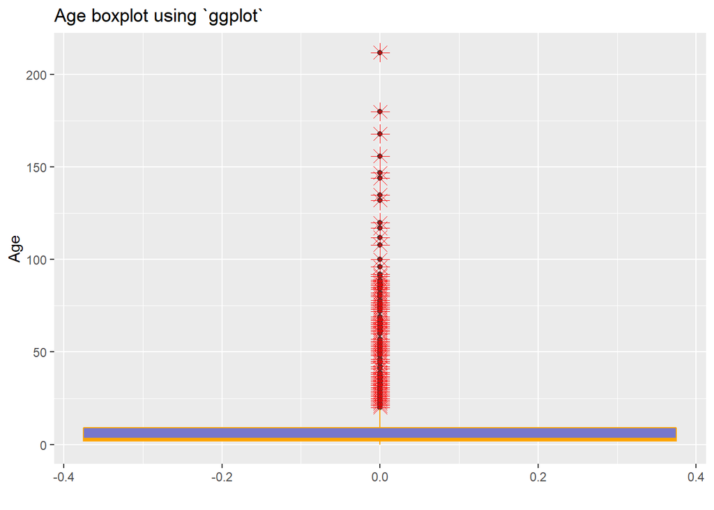

```r
#Boxplot
ggplot(data = tmpDatAge,aes(y = Age))+
  geom_boxplot() +
  geom_boxplot( colour="orange", fill="#7777cc", outlier.colour="red", outlier.shape=8, outlier.size=4) +
  labs(title="Age boxplot using `ggplot`",x="", y = "Age")
```

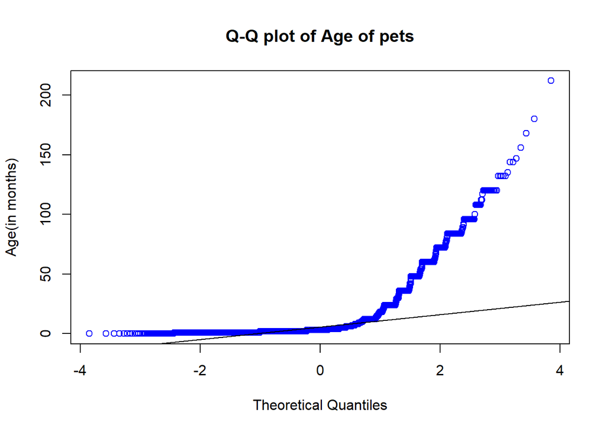

```r
#Q-Q plot
qqnorm(tmpDatAge$Age, main="Q-Q plot of Age of pets", ylab = "Age(in months)",col="blue")
qqline(tmpDatAge$Age)
```

This is photoAmt: number of photos included in a profile. Most of the listed pets only have few pictures.

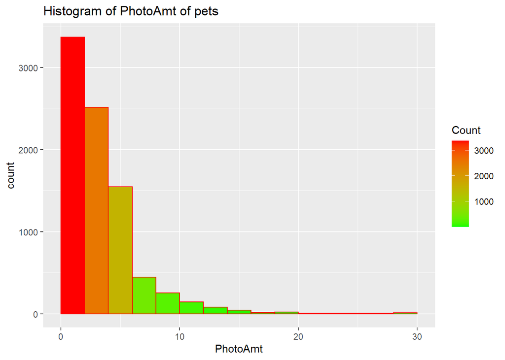

```r
tmpPhotoAmt = dat
tmpPhotoAmt$PhotoAmt = as.numeric(tmpPhotoAmt$PhotoAmt)

ggplot(data=tmpPhotoAmt, aes(PhotoAmt)) +
  geom_histogram(breaks=seq(0, 30, by=2),
                 col="red",
                 aes(fill=..count..)) +
  labs(title="Histogram of PhotoAmt of pets") +
  scale_fill_gradient("Count", low="green", high="red")
```

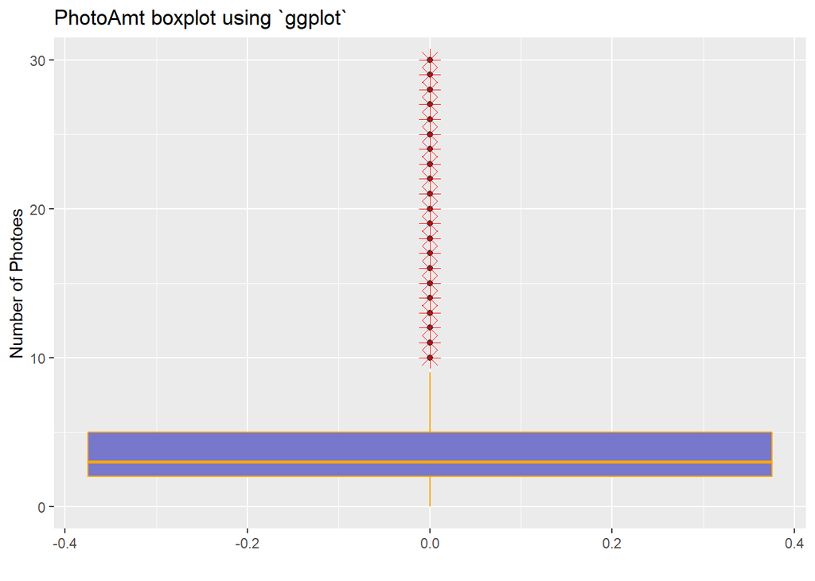

```r
#Boxplot
ggplot(data = tmpPhotoAmt,aes(y = PhotoAmt))+
  geom_boxplot() +
  geom_boxplot( colour="orange", fill="#7777cc", outlier.colour="red", outlier.shape=8, outlier.size=4) +
  labs(title="PhotoAmt boxplot using `ggplot`",x="", y = "Number of Photoes")
```

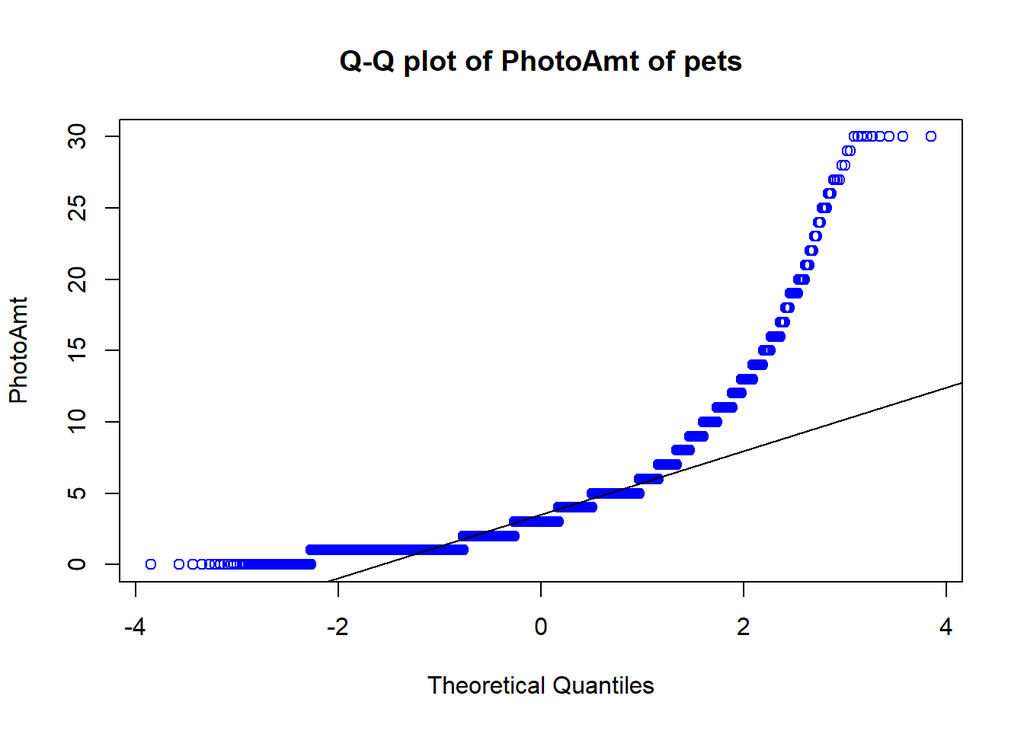

```r
#Q-Q plot
qqnorm(tmpPhotoAmt$PhotoAmt, main="Q-Q plot of PhotoAmt of pets", ylab = "PhotoAmt",col="blue")
qqline(tmpPhotoAmt$PhotoAmt)
```

### Categorical variable

Let’s us focus on some categorical variables.  
The first one is Type. There are two types: dog and cat.

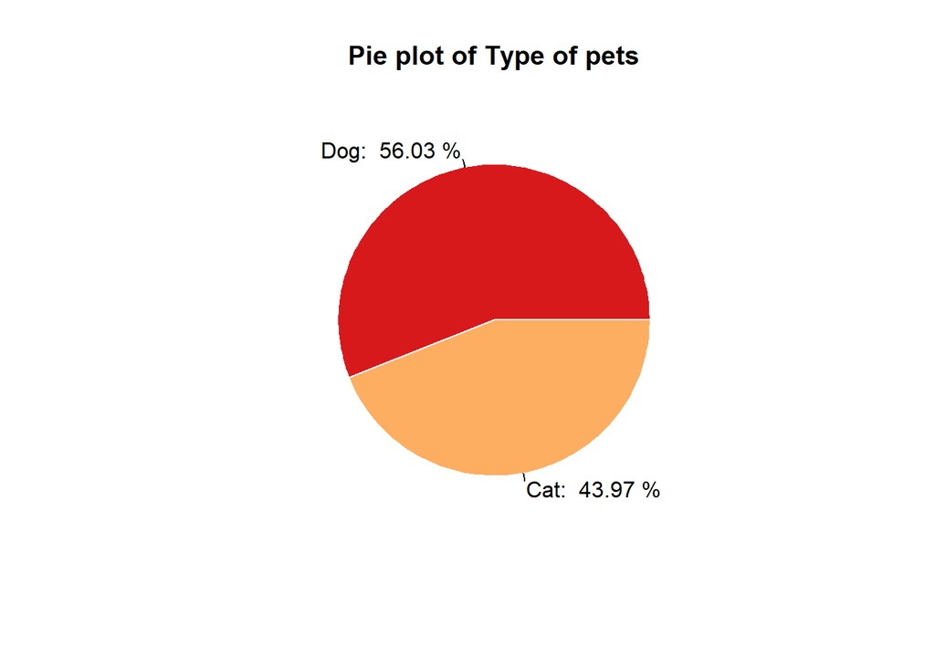

```r
dog = nrow(dat[dat$Type=="1",])
cat = nrow(dat[dat$Type=="2",])
totalamount = dog+cat

percentDog = format(dog/totalamount * 100, digits = 4)
percentCat = format(cat/totalamount * 100, digits = 4)

Prop <- c(dog,cat)
# Prepare a color palette. Here with R color brewer:
library(RColorBrewer)
myPalette <- brewer.pal(5, "RdYlGn")

# You can change the border of each area with the classical parameters:
pie(Prop , labels = c(paste("Dog: ",percentDog,"%"), paste("Cat: ",percentCat,"%")),
    main = "Pie plot of Type of pets", border="white", col=myPalette )
```

The second one is Gender. There are two genders: male and female.

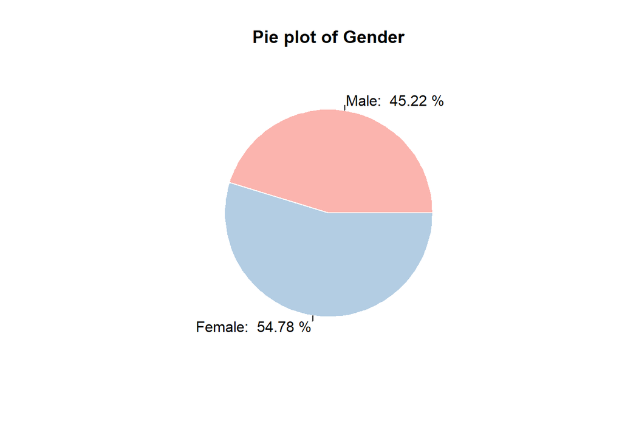

```r
#pie plot
male = nrow(dat[dat$Gender=="1",])
female = nrow(dat[dat$Gender=="2",])
percentMale = format(male/(male+female) * 100, digits = 4)
percentFemale = format(female/(male+female) * 100, digits = 4)
Prop <- c(male,female)
# Prepare a color palette. Here with R color brewer:
library(RColorBrewer)
myPalette <- brewer.pal(3, "Pastel1")

# You can change the border of each area with the classical parameters:
pie(Prop , labels = c(paste("Male: ", percentMale,"%"),paste("Female: ",percentFemale,"%")), main = "Pie plot of Gender", border="white", col=myPalette )
```

The third one is MaturitySize. There are four levels, which is small, medium, large, and extraLarge.

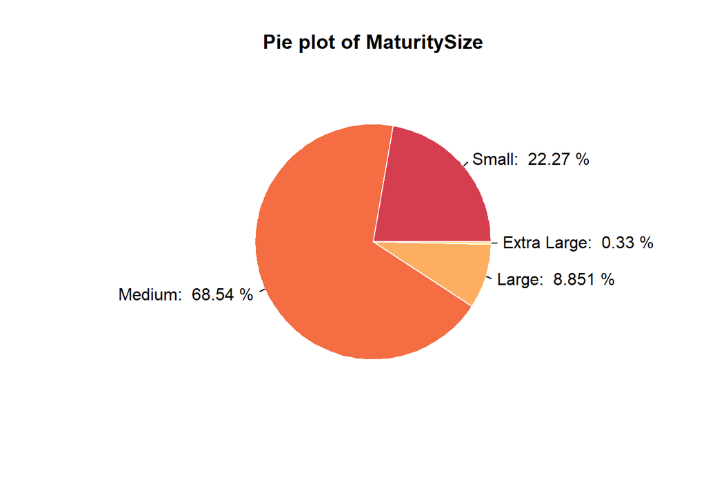

```r
small = nrow(dat[dat$MaturitySize=="1",])
medium = nrow(dat[dat$MaturitySize=="2",])
large = nrow(dat[dat$MaturitySize=="3",])
extraLarge = nrow(dat[dat$MaturitySize=="4",])
totalamount = small+medium+large+extraLarge

percentSmall = format(small/totalamount * 100, digits = 4)
percentMedium = format(medium/totalamount * 100, digits = 4)
percentLarge = format(large/totalamount * 100, digits = 4)
percentExtraLarge = format(extraLarge/totalamount * 100, digits = 4)
#pie plot
Prop <- c(small,medium,large,extraLarge)
# Prepare a color palette. Here with R color brewer:
library(RColorBrewer)
myPalette <- brewer.pal(8, "Spectral")

# You can change the border of each area with the classical parameters:
pie(Prop , labels = c(paste("Small: ",percentSmall,"%"), paste("Medium: ",percentMedium,"%"), paste("Large: ",percentLarge,"%"), paste("Extra Large: ",percentExtraLarge,"%")), main = "Pie plot of MaturitySize", border="white", col=myPalette )
```

The fourth one is FurLength. There are three levels, which is short, medium, and long.

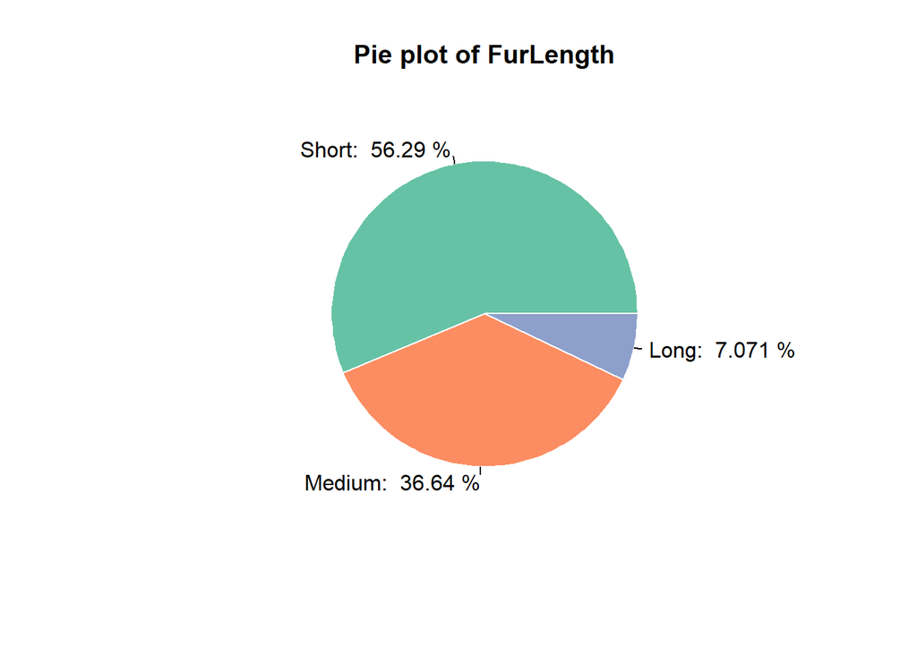

```r
short = nrow(dat[dat$FurLength=="1",])
medium = nrow(dat[dat$FurLength=="2",])
long = nrow(dat[dat$FurLength=="3",])
totalamount = short+medium+long

percentShort = format(short/totalamount * 100, digits = 4)
percentMedium = format(medium/totalamount * 100, digits = 4)
percentLong = format(long/totalamount * 100, digits = 4)


#pie plot
Prop <- c(short,medium,long)
# Prepare a color palette. Here with R color brewer:
library(RColorBrewer)
myPalette <- brewer.pal(3, "Set2")

# You can change the border of each area with the classical parameters:
pie(Prop , labels = c(paste("Short: ",percentShort,"%"), paste("Medium: ",percentMedium,"%"), paste("Long: ", percentLong,"%")), main = "Pie plot of FurLength", border="white", col=myPalette )
```

The fifth one is Vaccinated. There are three levels, which is Vaccinated, Unvaccinated, and Not Specified.

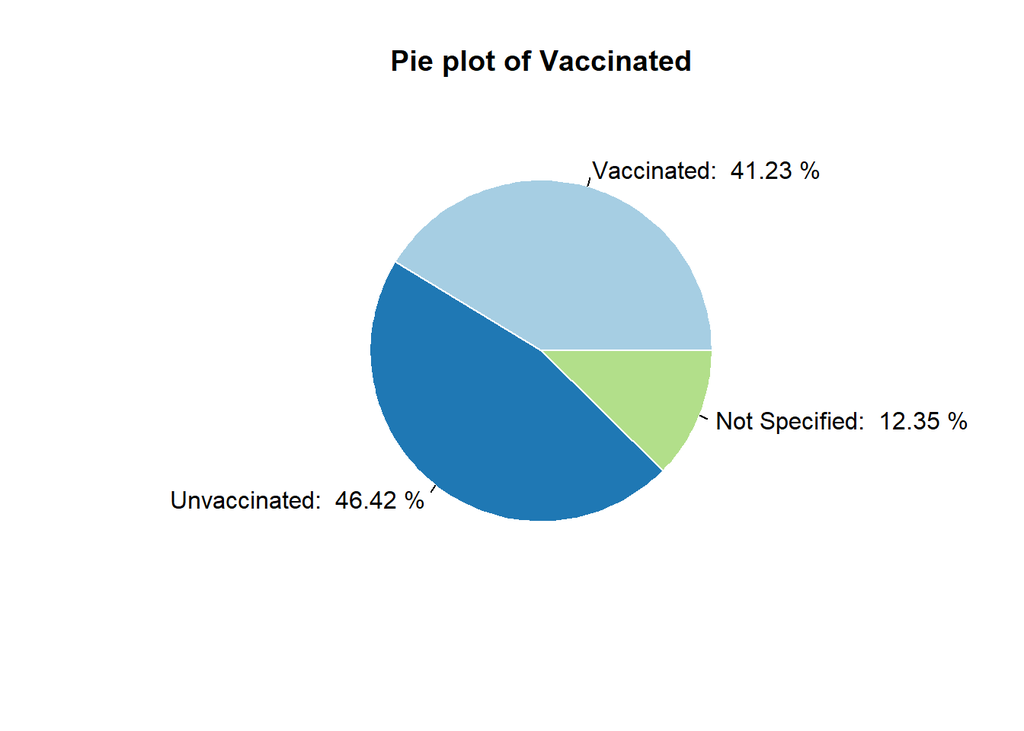

```r
vaccinatedYes = nrow(dat[dat$Vaccinated=="1",])
vaccinatedNo = nrow(dat[dat$Vaccinated=="2",])
vaccinatedNotSure = nrow(dat[dat$Vaccinated=="3",])
totalamount = vaccinatedYes+vaccinatedNo+vaccinatedNotSure

percentVaccinatedYes = format(vaccinatedYes/totalamount * 100, digits = 4)
percentVaccinatedNo = format(vaccinatedNo/totalamount * 100, digits = 4)
percentVaccinatedNotSure = format(vaccinatedNotSure/totalamount * 100, digits = 4)

#pie plot
Prop <- c(vaccinatedYes,vaccinatedNo,vaccinatedNotSure)
# Prepare a color palette. Here with R color brewer:
library(RColorBrewer)
myPalette <- brewer.pal(11,"Paired")

# You can change the border of each area with the classical parameters:
pie(Prop , labels = c(paste("Vaccinated: ",percentVaccinatedYes, "%"), paste("Unvaccinated: ",percentVaccinatedNo, "%"), paste("Not Specified: ",percentVaccinatedNotSure, "%")), main = "Pie plot of Vaccinated", border="white", col=myPalette )
```

# Chapter 4: Independent Variables EDA (Variance, T-Test, ANOVA)

Given all of our independent variables and our (now) numerical dependent variable, we wanted to know what most impacted the speed that an animal got adopted off PetFinder.

### SMART: Do dogs get adopted faster than cats?

First, we looked at animal type. In order to answer this question, we split the data into two groups, dogs and cats. Because there were only 2 samples we decided to use a two-sample t-test to evaluate if there was a significant difference between the average adoption speed of dogs and cats.

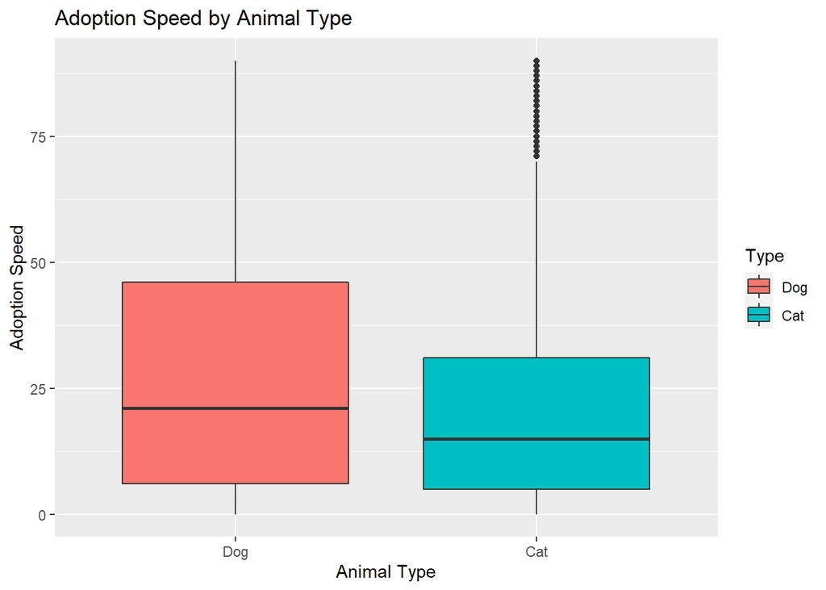

```r
library('ggplot2')
library('lmtest')

# boxplot of the animal type adoption speed
ggplot(data = dat, aes(y = ASnum, x = Type, fill = Type)) +
  geom_boxplot() +
  labs(title = "Adoption Speed by Animal Type", x = 'Animal Type', y = 'Adoption Speed') +
  scale_x_discrete(labels=c("1" = "Dog", "2" = "Cat")) +
  scale_fill_discrete(labels = c("Dog", "Cat"))
```

The first thing we had to do was a check of the homogeneity of variance. To do this we did a Breusch-Pagan (BP) test. The null hypothesis for this test is that the two groups have the same variance, while the alternative hypothesis is that the groups have difference variances.

```r
# running a variance check between dogs and cats
bp_dogscats = bptest(data = dat, formula = ASnum ~ Type)
bp_dogscats
```

```
##
##  studentized Breusch-Pagan test
##
## data:  ASnum ~ Type
## BP = 21, df = 1, p-value = 5e-06
```

Because the p_value is less than our alpha of 0.05 (p = 4.536^{-6}) we have to reject the null hypothesis that the groups have the same variance. Because of this, the two-sample t-test is not technically a valid statistical test, however we went ahead and performed the test regardless.

```r
# subsetting the data
dogs = subset(dat, dat$Type == 1) # only the dogs
cats = subset(dat, dat$Type == 2) # only the cats


# 2 sample t-test
dc_t = t.test(dogs$ASnum, cats$ASnum)
dc_t
```

```
##
##  Welch Two Sample t-test
##
## data:  dogs$ASnum and cats$ASnum
## t = 9, df = 8230, p-value <2e-16
## alternative hypothesis: true difference in means is not equal to 0
## 95 percent confidence interval:
##  4.01 6.18
## sample estimates:
## mean of x mean of y
##      28.9      23.8
```

The p_value of the t-test was also less than our alpha of 0.05 (p = 5.701^{-20}), allowing us to reject our null hypothesis that there is no difference between the means of the two groups. Because of this we can conclude that there is a difference in adoption speed between cats and dogs. Because the mean adoption speed for dogs is higher (slower) than the mean adoption speed for cats, we can conclude that dogs get adopted slower than cats, and that animal type does have an effect on adoption speed.

### SMART: Do physical attributes affect adoption speed?

The next question we wanted to answer was what physical attributes affect adoption speed. To answer this question we looked at the sex of the animal, the size, the fur length, and the vaccination status. Begining with the sex of the animal, we compared male animals to female animals.

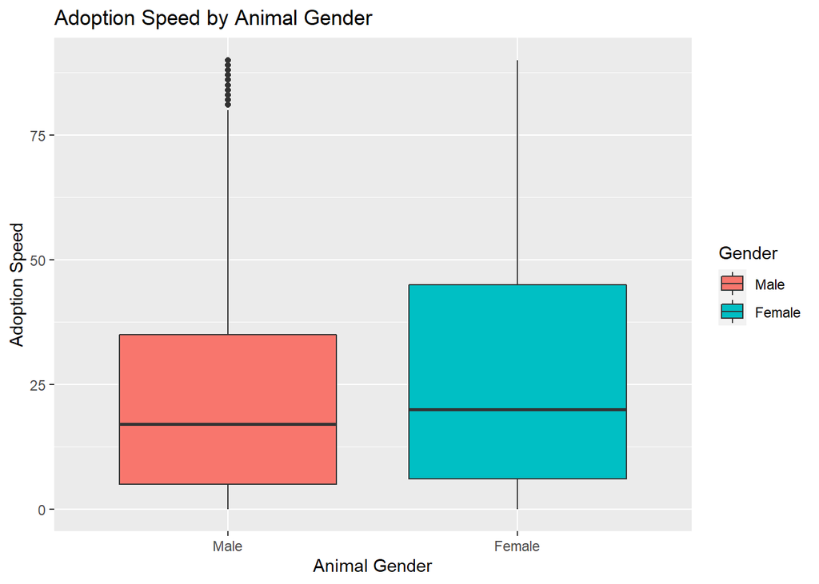

```r
### GENDER

# box plot of the adoption speed by gender
ggplot(data = dat, aes(y = ASnum, x = Gender, fill = Gender)) +
  geom_boxplot() +
  labs(title = "Adoption Speed by Animal Gender", x = 'Animal Gender', y = 'Adoption Speed') +
  scale_x_discrete(labels=c("1" = "Male", "2" = "Female")) +
  scale_fill_discrete(labels = c("Male", "Female"))
```

First we ran a variance check.

```r
### GENDER

# variance check for the gender
bp_mf = bptest(data = dat, formula = ASnum ~ Gender)
bp_mf
```

```
##
##  studentized Breusch-Pagan test
##
## data:  ASnum ~ Gender
## BP = 22, df = 1, p-value = 3e-06
```

Again, the BP test of variance had a p_value that was significant for our alpha of 0.05 (p = 3.494^{-6}), so we were able to reject the null hypothesis that the variance was equal between the groups. Again, this meant that a t-test was not appropriate, however we did a two-sample t-test regardless.

```r
### GENDER

# subsetting the data for the t-test
male = subset(dat, dat$Gender == 1) # only the male dogs
female = subset(dat, dat$Gender == 2) # only the female dogs

# 2 sample t-test
mf_t = t.test(male$ASnum, female$ASnum)
mf_t
```

```
##
##  Welch Two Sample t-test
##
## data:  male$ASnum and female$ASnum
## t = -6, df = 8354, p-value = 2e-10
## alternative hypothesis: true difference in means is not equal to 0
## 95 percent confidence interval:
##  -4.63 -2.45
## sample estimates:
## mean of x mean of y
##      24.7      28.2
```

Next we wanted to look at the size of the animals.

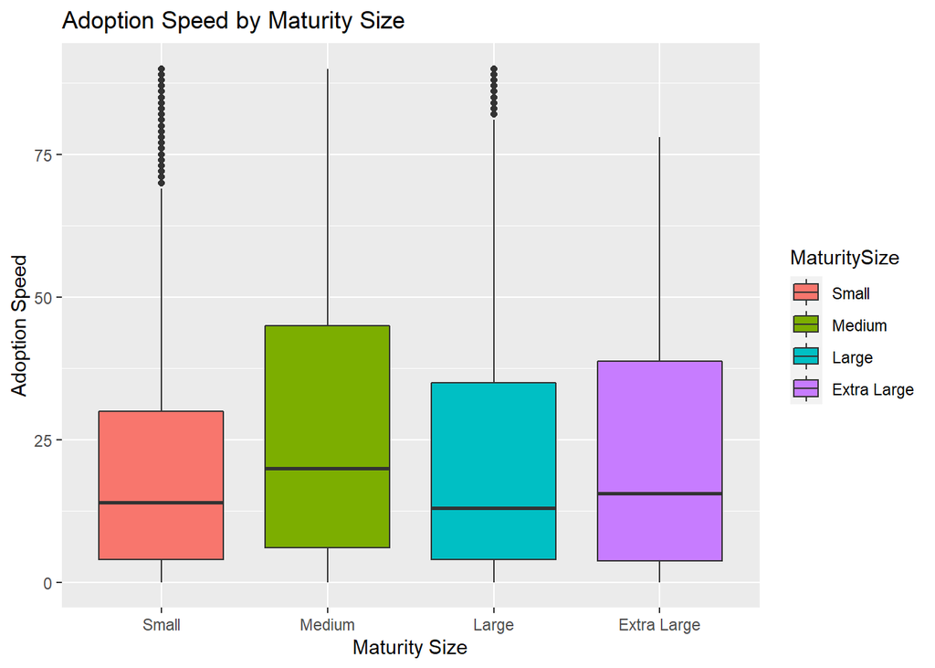

```r
### SIZE

# box plot of adoption speed and size
ggplot(data = dat, aes(y = ASnum, x = MaturitySize, fill = MaturitySize)) +
  geom_boxplot() +
  labs(title = "Adoption Speed by Maturity Size", x = 'Maturity Size', y = 'Adoption Speed') +
  scale_x_discrete(labels=c("1" = "Small", "2" = "Medium", "3" = "Large", "4" = "Extra Large")) +
  scale_fill_discrete(labels = c("Small", "Medium", "Large", "Extra Large"))
```

First we ran a variance check.

```r
### SIZE

# variance check for the size
bp_size = bptest(data = dat, formula = ASnum ~ MaturitySize)
bp_size
```

```
##
##  studentized Breusch-Pagan test
##
## data:  ASnum ~ MaturitySize
## BP = 24, df = 3, p-value = 3e-05
```

Looking at size we have over 2 samples, so we chose to run an ANOVA to test if the mean adoption speed differed between different sized animals. Once again, we ran a BP test of variance that produced a significant p_value (p = 2.824^{-5}), so an ANOVA is technically not appropriate. However we did run the analysis regardless.

```r
### SIZE

# running an anova on the size
anova_size = anova(aov(data = dat, ASnum ~ MaturitySize))
anova_size
```

```
## Analysis of Variance Table
##
## Response: ASnum
##                Df  Sum Sq Mean Sq F value Pr(>F)
## MaturitySize    3   54312   18104    27.6 <2e-16 ***
## Residuals    8481 5561523     656
## ---
## Signif. codes:  0 '***' 0.001 '**' 0.01 '*' 0.05 '.' 0.1 ' ' 1
```

```r
# running the post-hoc analysis
turkey_size = TukeyHSD(aov(data = dat, ASnum ~ MaturitySize))
turkey_size
```

```
##   Tukey multiple comparisons of means
##     95% family-wise confidence level
##
## Fit: aov(formula = ASnum ~ MaturitySize, data = dat)
##
## $MaturitySize
##       diff    lwr   upr p adj
## 2-1  5.700   3.96  7.44 0.000
## 3-1  0.930  -1.91  3.77 0.835
## 4-1  1.459 -11.07 13.99 0.991
## 3-2 -4.770  -7.32 -2.22 0.000
## 4-2 -4.241 -16.71  8.22 0.818
## 4-3  0.529 -12.14 13.19 1.000
```

We ended up with a significant p_value for the anova (p = 9.261^{-18}, NA), so we ran a TukeyHSD post-hoc test and found that the means between the small and medium dogs, and the medium and large dogs, were significantly different. We can therefore conclude that animal size does affect adoption speed.

Next we looked at fur length.

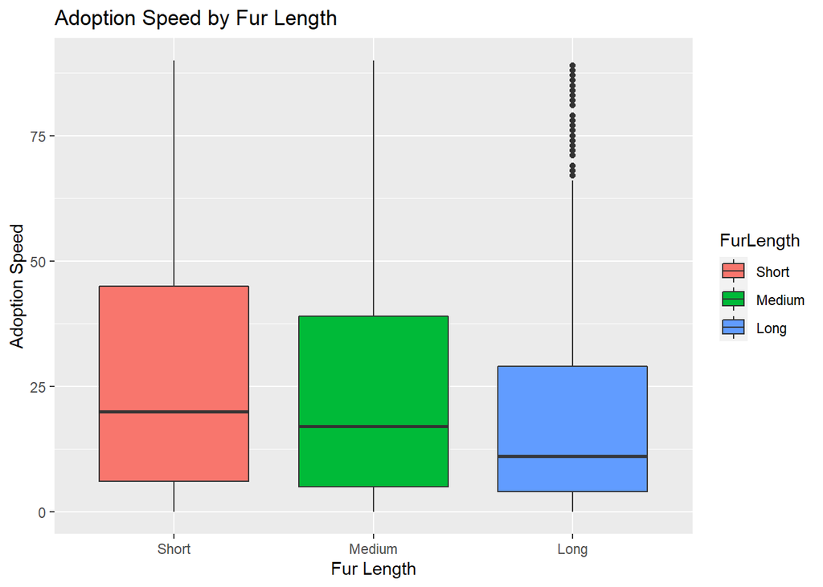

```r
### FURLENGTH

# fur length box plot
ggplot(data = dat, aes(y = ASnum, x = FurLength, fill = FurLength)) +
  geom_boxplot() +
  labs(title = "Adoption Speed by Fur Length", x = 'Fur Length', y = 'Adoption Speed') +
  scale_x_discrete(labels=c("1" = "Short", "2" = "Medium", "3" = "Long")) +
  scale_fill_discrete(labels = c("Short", "Medium", "Long"))
```

First we ran a variance check.

```r
### FURLENGTH

# variance check for fur length
bp_fur = bptest(data = dat, formula = ASnum ~ FurLength)
bp_fur
```

```
##
##  studentized Breusch-Pagan test
##
## data:  ASnum ~ FurLength
## BP = 22, df = 2, p-value = 2e-05
```

Once again our BP test of equal variance failed (p = 1.55^{-5}). However we continued with our analysis.

```r
### FURLENGTH

# anova for fur length
anova_fur = anova(aov(data = dat, ASnum ~ FurLength))
anova_fur
```

```
## Analysis of Variance Table
##
## Response: ASnum
##             Df  Sum Sq Mean Sq F value  Pr(>F)
## FurLength    2   37970   18985    28.9 3.2e-13 ***
## Residuals 8482 5577865     658
## ---
## Signif. codes:  0 '***' 0.001 '**' 0.01 '*' 0.05 '.' 0.1 ' ' 1
```

```r
# post-hoc tests for fur length
turkey_fur = TukeyHSD(aov(data = dat, ASnum ~ FurLength))
turkey_fur
```

```
##   Tukey multiple comparisons of means
##     95% family-wise confidence level
##
## Fit: aov(formula = ASnum ~ FurLength, data = dat)
##
## $FurLength
##      diff    lwr   upr p adj
## 2-1 -2.55  -3.94 -1.17     0
## 3-1 -7.80 -10.40 -5.19     0
## 3-2 -5.25  -7.93 -2.57     0
```

Because we have more than 2 samples we again decided to use an ANOVA to determine if the average adoption speed varied based on fur length. Our ANOVA did produce a significant result (p = 3.195^{-13}, NA) allowing us to reject the null hypothesis that the adoption speed was the same across fur lengths. Because we got a signficant result we again ran a TukeyHSD post-hoc analysis and found that the difference between each of the fur length groups was significant. We’re able to conclude that fur length does impact adoption speed.

Finally, we looked at vaccination status.

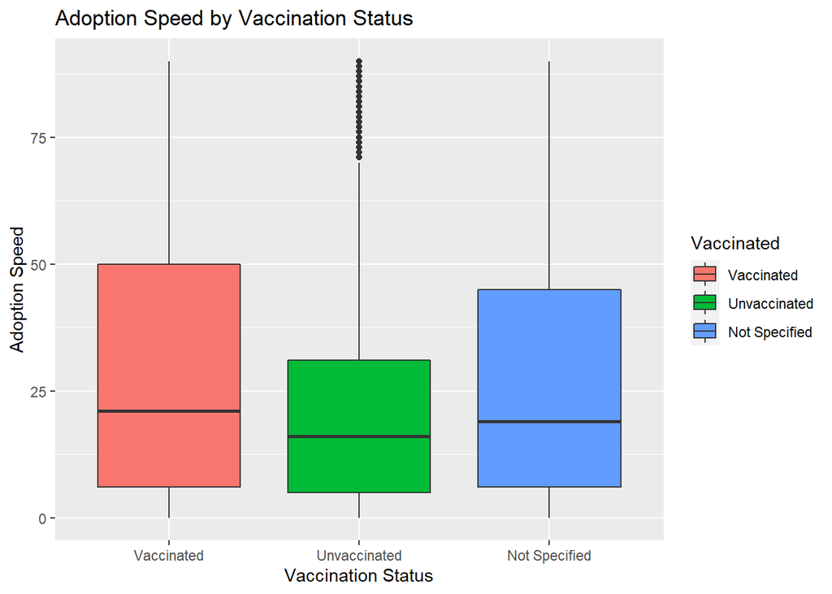

```r
### VACCINATED

# vaccination box plot
ggplot(data = dat, aes(y = ASnum, x = Vaccinated, fill = Vaccinated)) +
  geom_boxplot() +
  labs(title = "Adoption Speed by Vaccination Status", x = 'Vaccination Status', y = 'Adoption Speed') +
  scale_x_discrete(labels=c("1" = "Vaccinated", "2" = "Unvaccinated", "3" = "Not Specified")) +
  scale_fill_discrete(labels = c("Vaccinated", "Unvaccinated", "Not Specified"))
```

First we ran a variance check.

```r
### VACCINATED

# variance check for vaccination status
bp_vac = bptest(data = dat, formula = ASnum ~ Vaccinated)
bp_vac
```

```
##
##  studentized Breusch-Pagan test
##
## data:  ASnum ~ Vaccinated
## BP = 33, df = 2, p-value = 7e-08
```

Once again we were able to reject the null hypothesis of the BP variance test (p = 6.952^{-8}) but we continued with our analysis.

```r
### VACCINATED
# vaccination anova
anova_vac = anova(aov(data = dat, ASnum ~ Vaccinated))
anova_vac
```

```
## Analysis of Variance Table
##
## Response: ASnum
##              Df  Sum Sq Mean Sq F value Pr(>F)
## Vaccinated    2   62834   31417      48 <2e-16 ***
## Residuals  8482 5553001     655
## ---
## Signif. codes:  0 '***' 0.001 '**' 0.01 '*' 0.05 '.' 0.1 ' ' 1
```

```r
# post-hoc analysis for vaccination
turkey_vac = TukeyHSD(aov(data = dat, ASnum ~ Vaccinated))
turkey_vac
```

```
##   Tukey multiple comparisons of means
##     95% family-wise confidence level
##
## Fit: aov(formula = ASnum ~ Vaccinated, data = dat)
##
## $Vaccinated
##      diff   lwr     upr p adj
## 2-1 -5.79 -7.18 -4.3944 0.000
## 3-1 -2.15 -4.26 -0.0381 0.045
## 3-2  3.64  1.55  5.7223 0.000
```

The final conclusion from our analysis of categorical physical characteristics is that the difference in variance across the groups does not allow us to draw any meaningful conclusions. However, if we ignore that assumption for this sample of data, we are able to conclude that all the categorical physical characteristics, including the type of the animal, does impact the adoption speed of the animal.

# Chapter 5: Linear Modeling

### SMART: What numerical variables influence adoption speed?

We will run single variable OLS regressions for the three independent numerical variables. First, age.

```r
lm_age <- lm(ASnum ~ Age, data=dat )
table_lm_age <- tbl_regression(lm_age, intercept=TRUE)
table_lm_age
```

| **Characteristic** | **Beta** | **95% CI**<sup>1</sup> | **p-value** |
| --- | --- | --- | --- |
| (Intercept) | 26 | 25, 27 | <0.001 |
| Age | 0.06 | 0.03, 0.09 | <0.001 |

<sup>*1*</sup> CI = Confidence Interval

Lets look at VideoAmt next.

```r
lm_video <- lm(ASnum ~ VideoAmt, data=dat)
table_lm_video <- tbl_regression(lm_video, intercept=TRUE)
table_lm_video
```

| **Characteristic** | **Beta** | **95% CI**<sup>1</sup> | **p-value** |
| --- | --- | --- | --- |
| (Intercept) | 27 | 26, 27 | <0.001 |
| VideoAmt | 1.9 | 0.20, 3.6 | 0.028 |

<sup>*1*</sup> CI = Confidence Interval

Finally, lets check PhotoAmt.

```r
lm_photo <- lm(ASnum ~ PhotoAmt, data=dat)
table_lm_photo <-tbl_regression(lm_photo, intercept=TRUE)
table_lm_photo
```

| **Characteristic** | **Beta** | **95% CI**<sup>1</sup> | **p-value** |
| --- | --- | --- | --- |
| (Intercept) | 24 | 23, 25 | <0.001 |
| PhotoAmt | 0.78 | 0.61, 0.94 | <0.001 |

<sup>*1*</sup> CI = Confidence Interval

### SMART: What variables, both categorical and numerical, result in the best predictave model?

Using feature selection tools to identify best model.

Starting with generating an OLS model including all the variables we are considering.

```r
loadPkg("leaps")
reg_model <- regsubsets(ASnum~ Age + Gender + MaturitySize + FurLength + Vaccinated + VideoAmt + PhotoAmt, data = dat, nbest = 2, method = 'exhaustive')
```

```
## Reordering variables and trying again:
```

Let us now create plots for all 4 of the methods we want to use. Exhaustive, forward, backward, and sequential methods.

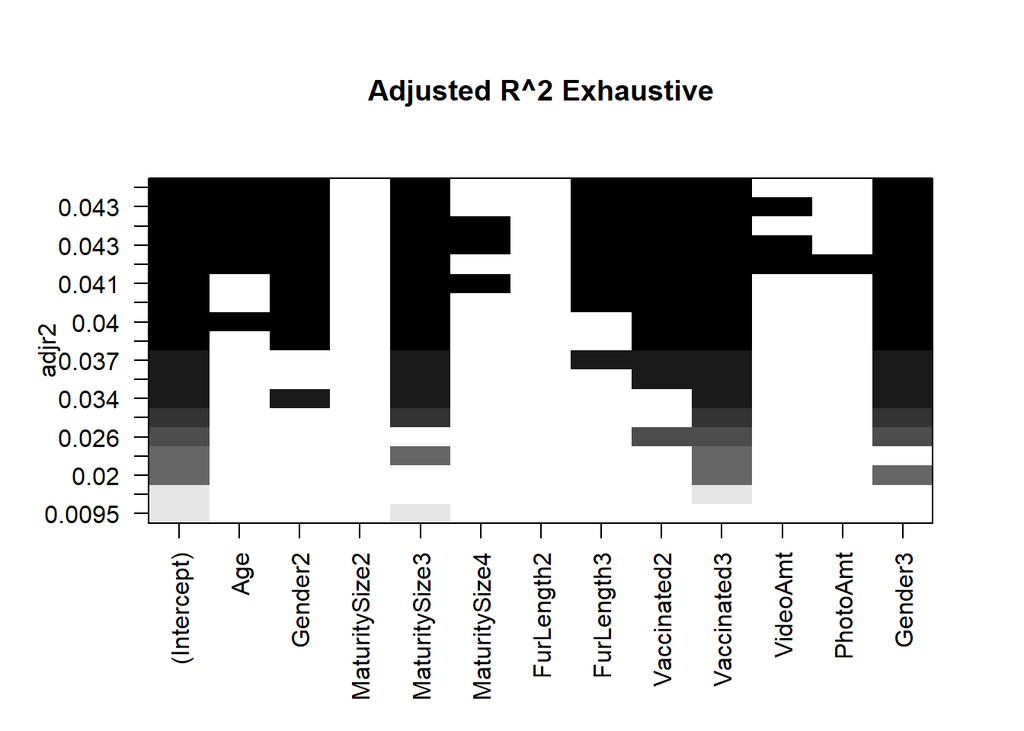

```r
plot(reg_model, scale = "adjr2", main = "Adjusted R^2 Exhaustive")
```

```r
reg_model_forward <- regsubsets(ASnum~ Age + Gender + MaturitySize + FurLength + Vaccinated + VideoAmt + PhotoAmt, data = dat, nbest = 2, method = 'forward')
```

```
## Reordering variables and trying again:
```

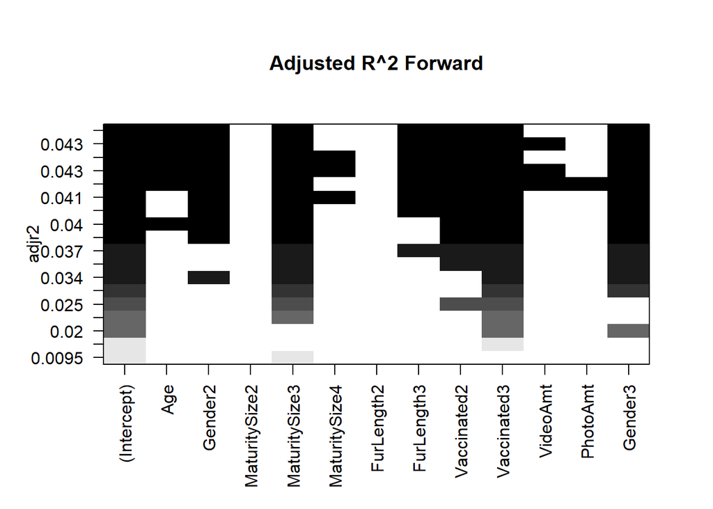

```r
plot(reg_model_forward, scale = "adjr2", main = "Adjusted R^2 Forward")
```

```r
reg_model_backward <- regsubsets(ASnum~ Age + Gender + MaturitySize + FurLength + Vaccinated + VideoAmt + PhotoAmt, data = dat, nbest = 2, method = 'backward')
```

```
## Reordering variables and trying again:
```

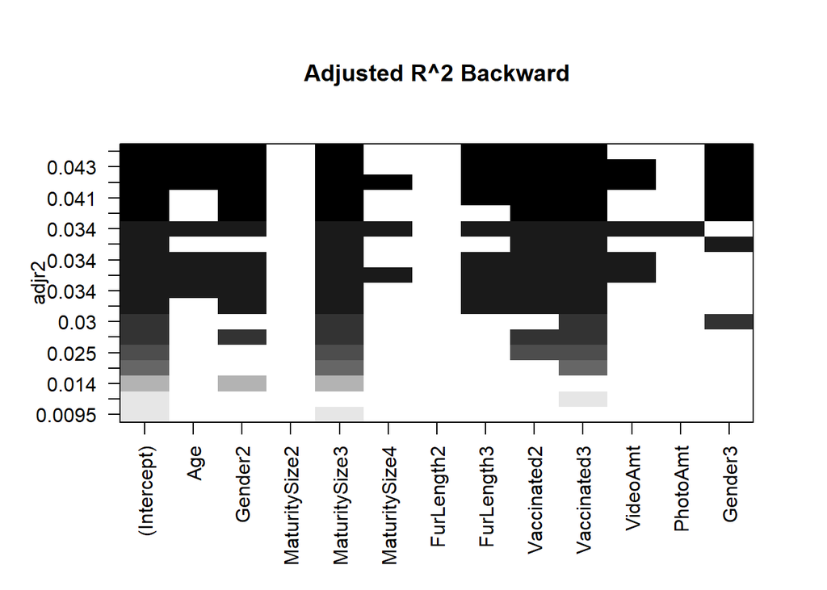

```r
plot(reg_model_backward, scale = "adjr2", main = "Adjusted R^2 Backward")
```

```r
reg_model_sequential <- regsubsets(ASnum~ Age + Gender + MaturitySize + FurLength + Vaccinated + VideoAmt + PhotoAmt, data = dat, nbest = 2, method = 'seqrep')
```

```
## Reordering variables and trying again:
```

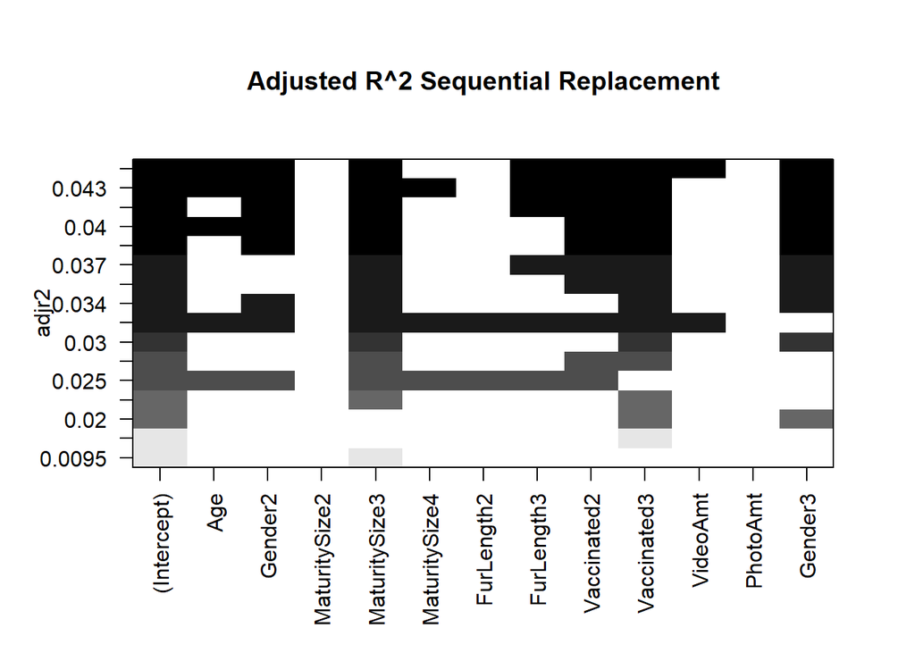

```r
plot(reg_model_sequential, scale = "adjr2", main = "Adjusted R^2 Sequential Replacement")
```

Dropping Age, MaturitySize3 between two models

```r
dat_drop_mat_4 <- subset(dat, ! dat$MaturitySize == 4)
dat_drop_mat_4 <- subset(dat_drop_mat_4, ! dat_drop_mat_4$Vaccinated== 3 )
dat_drop_mat_4_3 <- subset(dat_drop_mat_4, ! dat_drop_mat_4$MaturitySize == 3)
exh_for_back_model <- lm(ASnum~ Age + Gender + MaturitySize + FurLength + Vaccinated + PhotoAmt, data=dat_drop_mat_4)
table_exh_for_back_model <- tbl_regression(exh_for_back_model, intercept=TRUE)
add_vif(table_exh_for_back_model, statistic = "GVIF")
```

| **Characteristic** | **Beta** | **95% CI**<sup>1</sup> | **p-value** | **GVIF**<sup>1</sup> |
| --- | --- | --- | --- | --- |
| (Intercept) | 22 | 20, 23 | <0.001 |  |
| Age | 0.08 | 0.04, 0.12 | <0.001 | 1.2 |
| Gender |  |  |  | 1.0 |
| 1 | — | — |  |  |
| 2 | 3.6 | 2.5, 4.8 | <0.001 |  |
| MaturitySize |  |  |  | 1.1 |
| 1 | — | — |  |  |
| 2 | 5.0 | 3.6, 6.4 | <0.001 |  |
| 3 | 0.36 | -2.0, 2.7 | 0.8 |  |
| FurLength |  |  |  | 1.1 |
| 1 | — | — |  |  |
| 2 | -2.9 | -4.1, -1.7 | <0.001 |  |
| 3 | -8.2 | -11, -5.8 | <0.001 |  |
| Vaccinated |  |  |  | 1.1 |
| 1 | — | — |  |  |
| 2 | -5.3 | -6.5, -4.1 | <0.001 |  |
| PhotoAmt | 0.79 | 0.62, 1.0 | <0.001 | 1.0 |

<sup>*1*</sup> CI = Confidence Interval, GVIF = Generalized Variance Inflation Factor

This model gives an adjusted $R^2$ value of 0.037.

```r
sequential_model <- lm(ASnum ~ Gender + MaturitySize + FurLength + Vaccinated + PhotoAmt, data=dat_drop_mat_4_3)
table_sequential_model <- tbl_regression(sequential_model, intercept=TRUE)
add_vif(table_sequential_model, statistic = "GVIF")
```

| **Characteristic** | **Beta** | **95% CI**<sup>1</sup> | **p-value** | **GVIF**<sup>1</sup> |
| --- | --- | --- | --- | --- |
| (Intercept) | 23 | 22, 25 | <0.001 |  |
| Gender |  |  |  | 1.0 |
| 1 | — | — |  |  |
| 2 | 3.6 | 2.4, 4.8 | <0.001 |  |
| MaturitySize |  |  |  | 1.0 |
| 1 | — | — |  |  |
| 2 | 4.7 | 3.3, 6.1 | <0.001 |  |
| FurLength |  |  |  | 1.0 |
| 1 | — | — |  |  |
| 2 | -2.9 | -4.1, -1.6 | <0.001 |  |
| 3 | -7.3 | -10.0, -4.5 | <0.001 |  |
| Vaccinated |  |  |  | 1.0 |
| 1 | — | — |  |  |
| 2 | -6.4 | -7.6, -5.2 | <0.001 |  |
| PhotoAmt | 0.70 | 0.52, 0.88 | <0.001 | 1.0 |

<sup>*1*</sup> CI = Confidence Interval, GVIF = Generalized Variance Inflation Factor

This model gives an adjusted $R^2$ value of 0.0343

As the exhaustive-forward-backward model has a higher $R^2$ value than the sequential model, the conclusion is that the following model is the best model, and answer to our last SMART.

ASnum ~ Age + Gender 2 + MaturitySize2 + MaturitySize3 + FurLength2 + Furlength3 + Vaccinated2 + PhotoAmt

# Conclusion

### Categorical Variables

Type of animal, gender, size, fur length, and vaccination status all impact our dependent variable of adoption speed. However, the variance of these values is not equal, so any relationship that is discovered between these variables should be considered lightly.

### Linear Model

The best model: ASnum ~ Age + Gender 2 + MaturitySize2 + MaturitySize3 + FurLength2 + Furlength3 + Vaccinated2 + PhotoAmt.